# Lab 1 - Minhas perguntas sobre deputados

Arnaldo Gualberto

29 de março de 2017

No primeiro lab da disciplina *Fundamento em Ciência da Computação II*, o objetivo é analisar dados da câmara dos deputados para se familiarizar com as ferramentas de código que serão utilizadas no restante do curso. Em especial, deve utilizar essas ferramentas para responder as seguintes perguntas:

**a. Em que tipo de despesas os parlamentares gastam mais recursos de sua cota?**

**b. Que tipos de despesa tem valores que mais variam quando comparamos os deputados?**

O restante desse documento apresenta os passos necessários para respostas dessas perguntas, além de outras análises que considerei importante.

## 0. Includes e Settings

```r
library(dplyr, warn.conflicts = F)
library(readr)
library(ggplot2)
library(stringr)
library(knitr)

# Coloca todos os titulos dos gráficos centralizados
theme_update(plot.title = element_text(hjust=0.5))
```

## 1. Leitura e limpeza dos dados

```r
dados <- read_csv("dados/2015-2016-ate-mes-7.csv")
dados <- dados %>% select(sgPartido, txNomeParlamentar, sgUF, txtDescricao, vlrLiquido, ideCadastro) %>% filter(complete.cases(.))
names(dados) <- c("partido", "nome", "uf", "descricao", "valor_liq", "id_deputado")
```

Para essa análise, vou utilizar somente os dados dos deputados da Paraíba. Logo,

```r
dados_pb <- dados %>% filter(uf == "PB")
```

Primeiramente, vou analisar os dados na forma bruta em busca de valores estranhos ou duplicados imprimindo os valores únicos para os atributos relevantes nesse caso:

```r
"Partidos:";unique(dados_pb$partido);
```

```
## [1] "Partidos:"
```

```
##  [1] "PP"   "SD"   "PDT"  "DEM"  "PMDB" "PT"   "PSC"  "PSDB" "PSD"  "PR"
## [11] "PTB"  "PROS"
```

```r
"Nomes:";unique(dados_pb$nome);
```

```
## [1] "Nomes:"
```

```
##  [1] "AGUINALDO RIBEIRO"       "BENJAMIN MARANHÃO"
##  [3] "DAMIÃO FELICIANO"        "EFRAIM FILHO"
##  [5] "HUGO MOTTA"              "LUIZ COUTO"
##  [7] "MANOEL JUNIOR"           "MARCONDES GADELHA"
##  [9] "PEDRO CUNHA LIMA"        "RÔMULO GOUVEIA"
## [11] "VENEZIANO VITAL DO RÊGO" "WELLINGTON ROBERTO"
## [13] "WILSON FILHO"            "MAJOR FÁBIO"
## [15] "NILDA GONDIM"            "RUY CARNEIRO"
```

```r
"Descrições:";unique(dados_pb$descricao);
```

```
## [1] "Descrições:"
```

```
##  [1] "MANUTENÇÃO DE ESCRITÓRIO DE APOIO À ATIVIDADE PARLAMENTAR"
##  [2] "COMBUSTÍVEIS E LUBRIFICANTES."
##  [3] "DIVULGAÇÃO DA ATIVIDADE PARLAMENTAR."
##  [4] "PASSAGENS AÉREAS"
##  [5] "TELEFONIA"
##  [6] "SERVIÇOS POSTAIS"
##  [7] "ASSINATURA DE PUBLICAÇÕES"
##  [8] "LOCAÇÃO OU FRETAMENTO DE VEÍCULOS AUTOMOTORES"
##  [9] "Emissão Bilhete Aéreo"
## [10] "CONSULTORIAS, PESQUISAS E TRABALHOS TÉCNICOS."
## [11] "FORNECIMENTO DE ALIMENTAÇÃO DO PARLAMENTAR"
## [12] "HOSPEDAGEM ,EXCETO DO PARLAMENTAR NO DISTRITO FEDERAL."
## [13] "SERVIÇO DE TÁXI, PEDÁGIO E ESTACIONAMENTO"
## [14] "SERVIÇO DE SEGURANÇA PRESTADO POR EMPRESA ESPECIALIZADA."
## [15] "LOCAÇÃO OU FRETAMENTO DE AERONAVES"
```

```r
"ID dos Deputados:";unique(dados_pb$id_deputado)
```

```
## [1] "ID dos Deputados:"
```

```
##  [1] 160527  74040  74467 141422 160674  74041 141490  74470 178912 141536
## [11] 178913  74043 160636 149327 160564 160635
```

Analisando os resultados, vou efetuar as seguintes transformações nos dados:

1. Converter os nomes dos deputados e as descrições de despesas para *CamelCase*;
2. Converter as despesas *Emissão de Bilhete Aéreo* para *PASSAGENS AÉREAS*, já que representam a mesma coisa.
3. Remover os valores líquidos negativos - que representam reembolso - para não atrapalhar nos cálculos sobre os valores.

```r
dados_pb <- dados_pb %>%
  mutate(descricao = ifelse(descricao == "Emissão Bilhete Aéreo", "PASSAGENS AÉREAS", descricao)) %>%
  mutate(nome = stringr::str_to_title(nome)) %>%
  mutate(descricao = stringr::str_to_title(descricao)) %>%
  filter(valor_liq > 0)
```

## 2. Visualizações dos dados

Agora que eu realizei as limpezas que queria nos meus dados, vou dar inicio a parte da estatística descritiva e visualização.

### 2.1 Estatística Descritiva

Primeiramente, vou analisar os valores estatísticos descritivos da variável *valor_liq*:

```r
min(dados_pb$valor_liq); mean(dados_pb$valor_liq); median(dados_pb$valor_liq); max(dados_pb$valor_liq)
```

```
## [1] 0.08
```

```
## [1] 891.7701
```

```
## [1] 230.015
```

```
## [1] 64000
```

Achei estranho o valor mínimo líquido ser de R$0,08. O que será que é?

```r
kable(filter(dados_pb, valor_liq == min(valor_liq)))
```

| partido | nome | uf | descricao | valor_liq | id_deputado |
| --- | --- | --- | --- | --- | --- |
| PMDB | Veneziano Vital Do Rêgo | PB | Telefonia | 0.08 | 178913 |
| PROS | Major Fábio | PB | Telefonia | 0.08 | 149327 |

A princípio, nada estranho. Quero observar agora, a distribuição dessa variável:

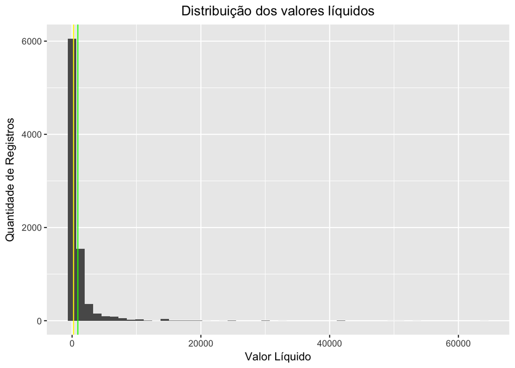

```r
dados_pb %>%
  ggplot(aes(x = valor_liq)) +
  geom_histogram(bins = 50) +
  geom_vline(xintercept = mean(dados_pb$valor_liq), colour = "green") +
  geom_vline(xintercept = median(dados_pb$valor_liq), colour = "yellow") +
  ggtitle("Distribuição dos valores líquidos") +
  xlab("Valor Líquido") +
  ylab("Quantidade de Registros")
```

Pelo gráfico acima, percebe-se que a maior parte dos gastos dos deputados são de baixo valor, apesar de elas serem bem frequentes. Além disso, é possível ver que **a distribuição não é simétrica** e que a média (linha verde) não é tão distante da mediana (linha amarela) dos gastos.

Como o gráfico acima se parece com uma curva logarítimica, a título de curiosidade, vou plotar o mesmo gráfico em escala logarítimica:

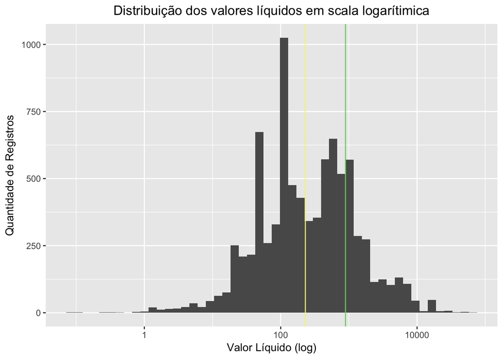

```r
dados_pb %>%
  ggplot(aes(x = valor_liq)) +
  geom_histogram(bins = 50) +
  geom_vline(xintercept = mean(dados_pb$valor_liq), colour = "green") +
  geom_vline(xintercept = median(dados_pb$valor_liq), colour = "yellow") +
  scale_x_log10() +
  ggtitle("Distribuição dos valores líquidos em scala logarítimica") +
  xlab("Valor Líquido (log)") +
  ylab("Quantidade de Registros")
```

Como eu esperava, agora a curva aproxima-se de uma distribuição normal. Antes de finalizar essa seção, quero observar também a distribuição das descrições das despesas:

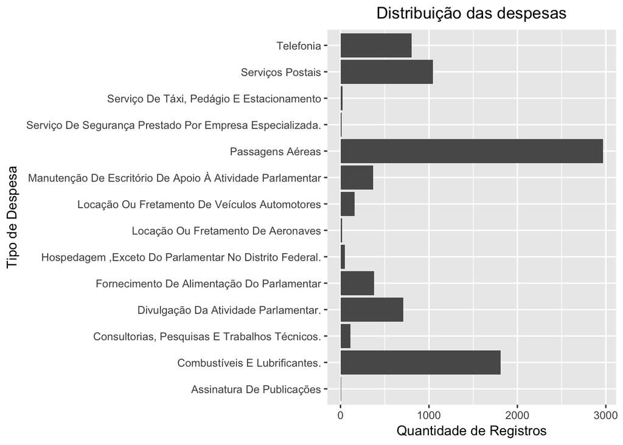

```r
dados_pb %>%
  group_by(descricao) %>%
  ggplot(aes(x = descricao)) +
  geom_bar() +
  ggtitle("Distribuição das despesas") +
  xlab("Tipo de Despesa") +
  ylab("Quantidade de Registros") +
  coord_flip()
```

Logo de cara, é fácil perceber que *Passagens Aéreas* e *Combustíveis e Lubrificantes* são as despesas mais comuns dos deputados.

### 2.2 Visualizações

Primeiramente, quero saber quantas despesas cada partido tem na tabela:

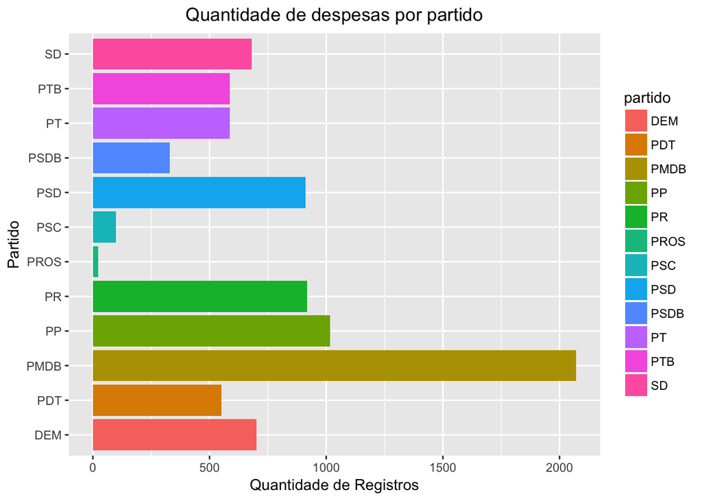

```r
dados_pb %>%
  ggplot(aes(x = partido, fill=partido)) +
  geom_bar() +
  ggtitle("Quantidade de despesas por partido") +
  ylab("Quantidade de Registros") +
  xlab("Partido") +
  coord_flip()
```

A principio, **o PMDB é o partido que mais tem registros de gastos na Paraíba, com mais de 2000 despesas**. Porém, temos de verificar primeiro a quantidade de deputados por partido no estado:

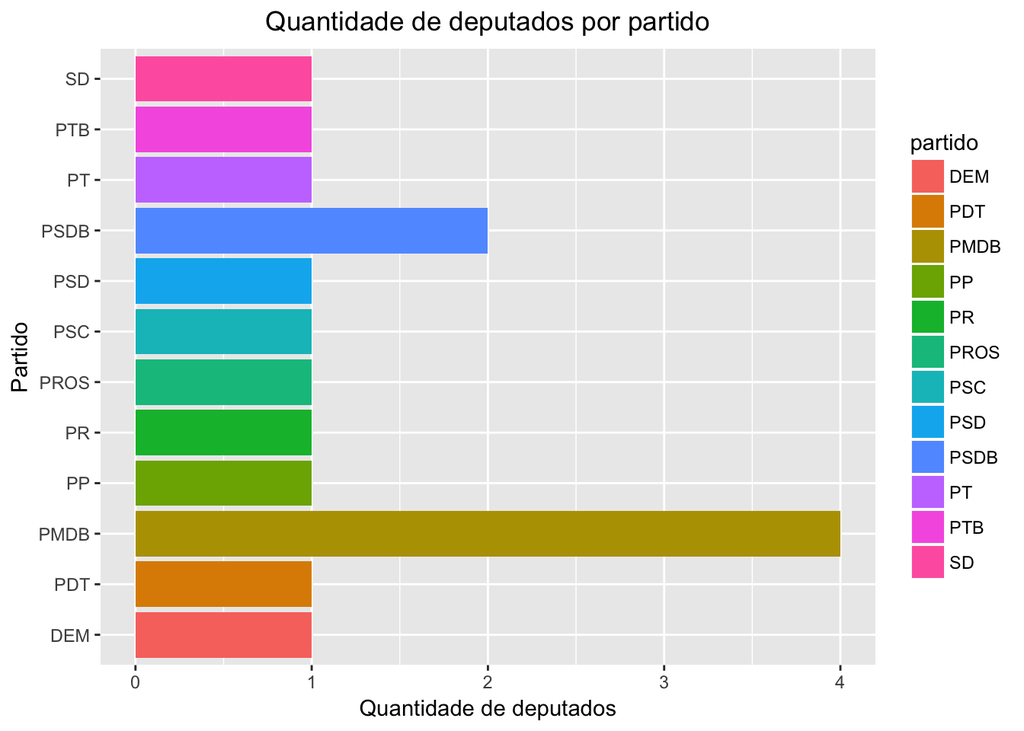

```r
dados_sum <- dados_pb %>%
  group_by(partido) %>%
  summarise(qtde = length(unique(id_deputado)))

dados_sum %>%
  ggplot(aes(x = partido, y = qtde, fill=partido)) +
  geom_bar(stat = "identity") +
  ggtitle("Quantidade de deputados por partido") +
  xlab("Partido") +
  ylab("Quantidade de deputados") +
  coord_flip()
```

Pode-se ver que **apenas o PMDB e o PSDB são os únicos partidos com mais de um representante**. Então, daqui para frente, vou concentrar minhas análises por deputado, já que em quase todos os casos o valor gasto por um deputado será igual ao do partido.

Agora, quero saber quanto cada deputado gastou:

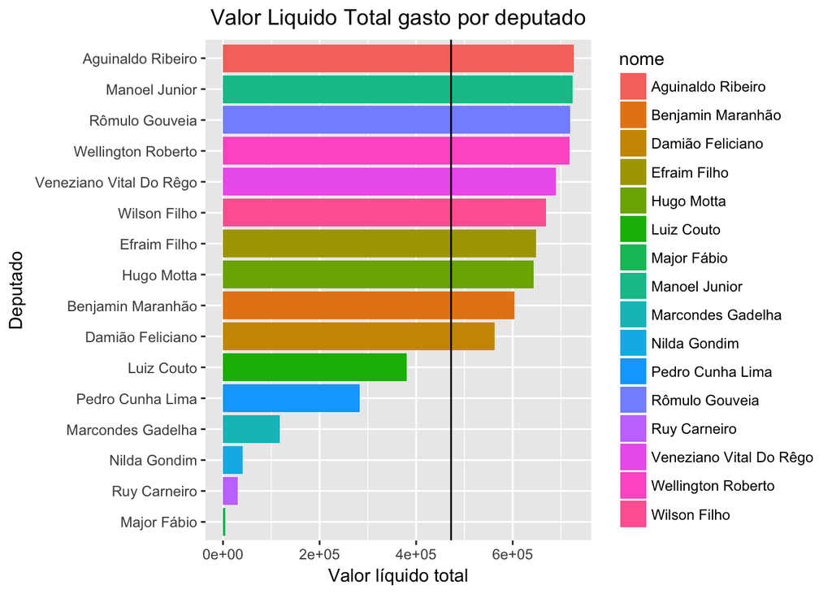

```r
dados_sum <- dados_pb %>%
  group_by(nome) %>%
  summarise(total = sum(valor_liq)) %>%
  arrange(total)

dados_sum %>%
  ggplot(aes(x = reorder(nome, total), y = total, fill=nome)) +
  geom_bar(stat = 'identity') +
  geom_hline(yintercept = mean(dados_sum$total)) +
  ggtitle("Valor Liquido Total gasto por deputado") +
  xlab("Deputado") +
  ylab("Valor líquido total") +
  coord_flip()
```

Pelo gráfico acima, pode-se ver que **Aguinaldo Ribeiro é o deputado que mais gasta recursos, seguido por Manoel Junior e Rômulo Gouveia**. Além disso, **10 dos 16 deputados gastam mais que a média (linha preta: R$ 472.415,20)**. **Major Fábio e Ruy Carneiro são os deputados que menos gastam**.

Vamos analisar o maior gasto dos deputados que mais e menos gastam, respectivamente:

```r
kable(dados_pb %>%
  filter(nome == "Aguinaldo Ribeiro") %>%
  filter(valor_liq == max(valor_liq)))
```

| partido | nome | uf | descricao | valor_liq | id_deputado |
| --- | --- | --- | --- | --- | --- |
| PP | Aguinaldo Ribeiro | PB | Divulgação Da Atividade Parlamentar. | 54000 | 160527 |

```r
kable(dados_pb %>%
  filter(nome == "Major Fábio") %>%
  filter(valor_liq == max(valor_liq)))
```

| partido | nome | uf | descricao | valor_liq | id_deputado |
| --- | --- | --- | --- | --- | --- |
| PROS | Major Fábio | PB | Passagens Aéreas | 2740.98 | 149327 |

Agora eu fiquei curioso: **Qual foi o maior gasto dentre todos os deputados? De quem foi esse gasto?**

```r
kable(dados_pb %>%
  filter(valor_liq == max(valor_liq)))
```

| partido | nome | uf | descricao | valor_liq | id_deputado |
| --- | --- | --- | --- | --- | --- |
| SD | Benjamin Maranhão | PB | Divulgação Da Atividade Parlamentar. | 64000 | 74040 |

E a resposta é: **Benjamin Maranhão, que gastou R$ 64.000,00 com *Divulgação da Atividade Parlamentar*** (que desperdício!). Se compararmos com os dados do último gráfico, podemos perceber que **só esse gasto representa mais de 10% de todo os recursos que ele gastou**.

## 3. Respostas as questões

Agora que eu fiz as análises preliminares, vou responder as questões do exercício:

#### a. Em que tipo de despesas os parlamentares gastam mais recursos de sua cota?

Para responder essa pergunta, vou simplesmente agrupar os dados por tipo de despesa e sumarizar os dados pela soma do valor líquido total.

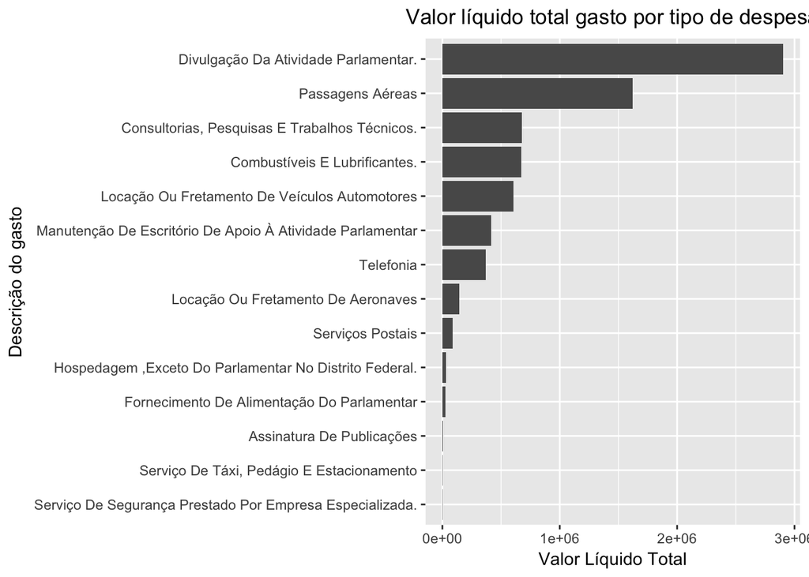

```r
dados_sum <- dados_pb %>%
  group_by(descricao) %>%
  summarise(total = sum(valor_liq)) %>%
  arrange(total)

dados_sum %>%
  ggplot(aes(x = reorder(descricao, total), y = total)) +
  geom_bar(stat = "identity") +
  xlab("Descrição do gasto") +
  ylab("Valor Líquido Total") +
  ggtitle("Valor líquido total gasto por tipo de despesa") +
  coord_flip()
```

> É fácil perceber pelo gráfico que **a *Divulgação da atividade parlamentar* é o tipo de despesa que os deputados mais gastam recursos da cota**, seguido por *Passagens Aéreas*, que é praticamente metade desse valor.

Fiquei curioso para saber como seria esse gráfico por deputado.

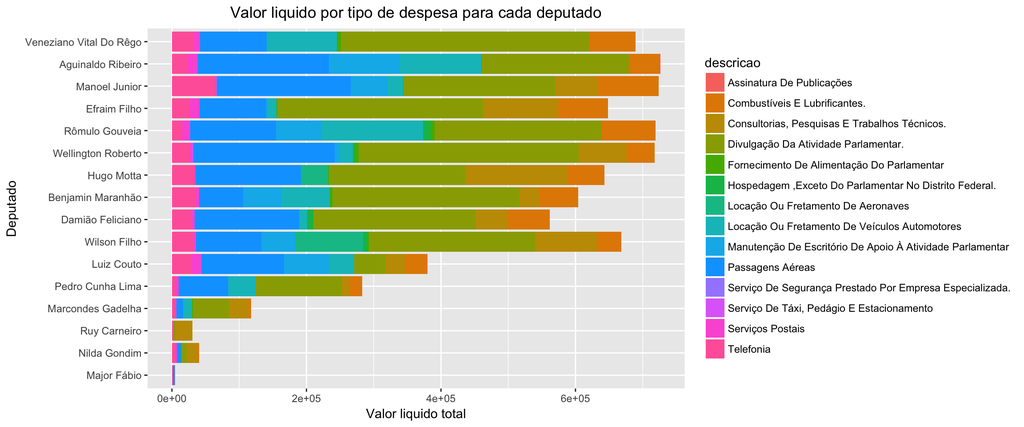

```r
dados_sum <- dados_pb %>%
  group_by(nome, descricao) %>%
  summarise(total = sum(valor_liq)) %>%
  arrange(total)

dados_sum %>%
  ggplot(aes(x = reorder(nome, total), y = total, fill=descricao)) +
  geom_bar(stat = "identity") +
  ggtitle("Valor liquido por tipo de despesa para cada deputado") +
  xlab("Deputado") +
  ylab("Valor liquido total") +
  coord_flip()
```

Apesar de não ser possível ver o gráfico para todos os deputados claramente, ainda assim é possível ver que **o gasto com *Divulgação da Atividade Parlamentar* é a despesa mais presente na maioria dos deputados**.

Para tornar fácil a visualização para todos os deputados, vou plotar o gráfico acima com as proporções de cada tipo de despesa para cada deputado:

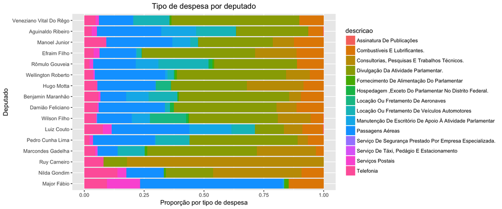

```r
dados_sum <- dados_pb %>%
  group_by(nome, descricao) %>%
  summarise(total = sum(valor_liq))

dados_sum %>%
  ggplot(aes(x = reorder(nome, total), y = total, fill=descricao)) +
  geom_bar(stat = "identity", position = "fill") +
  ggtitle("Tipo de despesa por deputado") +
  xlab("Deputado") +
  ylab("Proporção por tipo de despesa") +
  coord_flip()
```

Agora é possível observar que **apenas os deputados Luiz Couto, Ruy Carneiro, Nilda Gondim e Major Fábio gastam mais recursos proporcionalmente com outros tipos de despesas que em relação a *Divulgação da Atividade Parlamentar***.

O gráfico abaixo plota todas as despesas dos deputados distribuidas pelos valores e separadas por tipo.

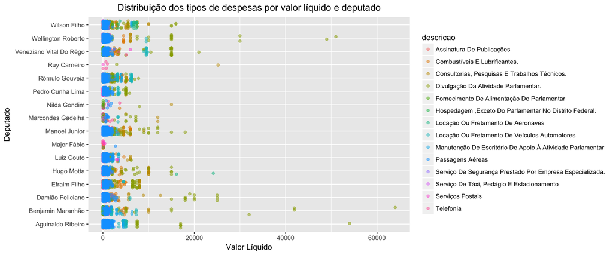

```r
dados_sum <- dados_pb %>%
  group_by(nome, descricao)

dados_sum %>%
  ggplot(aes(x=nome, y=valor_liq, colour=descricao)) +
  #geom_point(alpha=0.5) +
  geom_point(alpha=0.5, position = position_jitter(width = 0.3)) +
  ggtitle("Distribuição dos tipos de despesas por valor líquido e deputado") +
  xlab("Deputado") +
  ylab("Valor Líquido") +
  coord_flip()
```

```r
kable(filter(dados_pb, valor_liq >= 20000))
```

| partido | nome | uf | descricao | valor_liq | id_deputado |
| --- | --- | --- | --- | --- | --- |
| SD | Benjamin Maranhão | PB | Divulgação Da Atividade Parlamentar. | 41890 | 74040 |
| PDT | Damião Feliciano | PB | Divulgação Da Atividade Parlamentar. | 25000 | 74467 |
| PMDB | Veneziano Vital Do Rêgo | PB | Divulgação Da Atividade Parlamentar. | 21000 | 178913 |
| PP | Aguinaldo Ribeiro | PB | Divulgação Da Atividade Parlamentar. | 54000 | 160527 |
| SD | Benjamin Maranhão | PB | Divulgação Da Atividade Parlamentar. | 64000 | 74040 |
| SD | Benjamin Maranhão | PB | Divulgação Da Atividade Parlamentar. | 41890 | 74040 |
| SD | Benjamin Maranhão | PB | Divulgação Da Atividade Parlamentar. | 32000 | 74040 |
| PDT | Damião Feliciano | PB | Divulgação Da Atividade Parlamentar. | 20000 | 74467 |
| PDT | Damião Feliciano | PB | Divulgação Da Atividade Parlamentar. | 20000 | 74467 |
| PDT | Damião Feliciano | PB | Divulgação Da Atividade Parlamentar. | 20000 | 74467 |
| PDT | Damião Feliciano | PB | Divulgação Da Atividade Parlamentar. | 25000 | 74467 |
| PDT | Damião Feliciano | PB | Divulgação Da Atividade Parlamentar. | 25000 | 74467 |
| PMDB | Hugo Motta | PB | Locação Ou Fretamento De Aeronaves | 24150 | 160674 |
| PSDB | Ruy Carneiro | PB | Consultorias, Pesquisas E Trabalhos Técnicos. | 25200 | 160635 |
| PR | Wellington Roberto | PB | Divulgação Da Atividade Parlamentar. | 51000 | 74043 |
| PR | Wellington Roberto | PB | Divulgação Da Atividade Parlamentar. | 49000 | 74043 |
| PR | Wellington Roberto | PB | Divulgação Da Atividade Parlamentar. | 30000 | 74043 |
| PR | Wellington Roberto | PB | Divulgação Da Atividade Parlamentar. | 30000 | 74043 |

A tabela acima mostra que, como já vimos anteriormente, grandes quantias de dinheiro são gastas com *Divulgação da Atividade Parlamentar*. Porém, há dois dados interessantes: **o deputado Ruy Carneiro gastou R$25.200,00 com *Consultorias, Pesquisas e Trabalhos Técnicos***; **o deputado Hugo Mota fretou/alugou uma Aeronave por R$24.150,00!!**.

De acordo com o [site da camara](http://www.camara.leg.br/cota-parlamentar/index.jsp), esse gasto do deputado Ruy Carneiro foi referente a um [censo estatístico](http://www.camara.gov.br/cota-parlamentar//documentos/publ/2276/2015/5580561.pdf) realizado na cidade de Bayeux. Já **Hugo Mota, fez 9 viagens de avião fretado num período de 17 dias** entre João Pessoa-PB, Recife-PE, Guarabira-PB, e Maceió-AL (ver [recibo](http://www.camara.gov.br/cota-parlamentar//documentos/publ/2271/2015/5787224.pdf)).

Outra forma de visualizar o gráfico acima, seria gerar um hetmap mostrando a quantidade de registros por tipo de despesa para cada deputado:

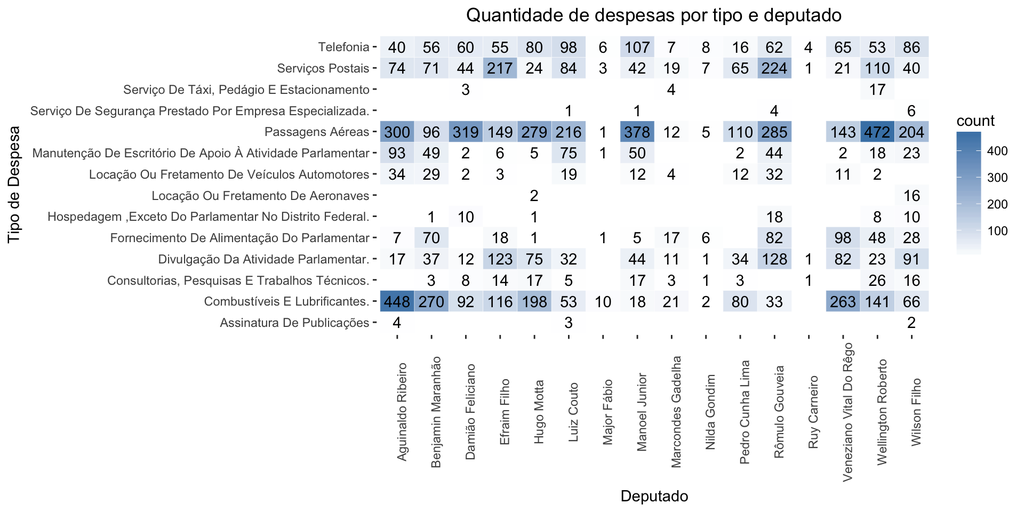

```r
dados_sum <- dados_pb %>%
  group_by(nome, descricao) %>%
  summarise(count = n())

dados_sum %>%
  ggplot(aes(x = nome, y = descricao, fill=count)) +
  geom_tile(colour = "white", size=0.1) +
  geom_text(aes(label = count)) +
  #scale_fill_gradient(low = "white", high = "steelblue", na.value = "white") +
  scale_fill_continuous(na.value = "white", low="white", high="steelblue") +
  theme(panel.background = element_rect(fill = "white", colour = "white")) +
  theme(axis.text.x = element_text(angle = 90)) +
  xlab("Deputado") +
  ylab("Tipo de Despesa") +
  ggtitle("Quantidade de despesas por tipo e deputado")
```

Analisando o gráfico acima, pode-se observar novamente que *Passagens Aéreas* são os gastos mais comuns dos deputados, seguido por *Combustíveis e Lubrificantes* e *Serviços Postais*. **O deputado Wellington Roberto é o deputado que mais comprou passagens aéreas (472)**. **Aguinaldo Ribeiro, por sua vez, teve 448 despesas com *Combustíveis e Lubrificantes* (448)**, quase o dobro do segundo deputado nessa mesma categoria (Benjamin Maranhão com 270 despesas). **Também é possível ver que *Assinatura de Publicações* e *Serviço de Segurança Prestado por Empresas Especializadas*** são os tipos de despesas menos utilizados pelos deputados.

#### b. Que tipos de despesa tem valores que mais variam quando comparamos os deputados?

Vamos agora analisar os tipos de despesa que tem valores que mais variam ao comparar os deputados.

Para responder essa pergunta, vou utilizar um gráfico do tipo *error bar* mostrando a variação de entre os valores mínimo e máximo para cada tipo de despesa:

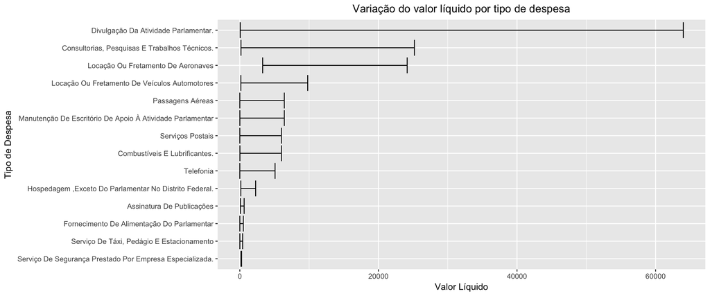

```r
dados_sum <- dados_pb %>%
  group_by(descricao) %>%
  summarise(max = max(valor_liq), min = min(valor_liq)) %>%
  arrange(max-min)

dados_sum %>%
  ggplot(aes(x = reorder(descricao, max-min))) +
  geom_errorbar(aes(ymax = max, ymin = min))+
  ggtitle("Variação do valor líquido por tipo de despesa") +
  xlab("Tipo de Despesa") +
  ylab("Valor Líquido") +
  coord_flip()
```

Logo, pelo gráfico acima, a resposta é:

> **a *Divulgação da Atividade Parlamentar* é o tipo de despesa que mais varia entre todos os deputados, seguido por *Consultorias, Pesquisas e Trabalhos Técnicos* e *Locação ou Fretamento de Aeronaves***.

Finalmente, resolvi plotar o mesmo gráfico separando os tipos de despesa para cada Deputado:

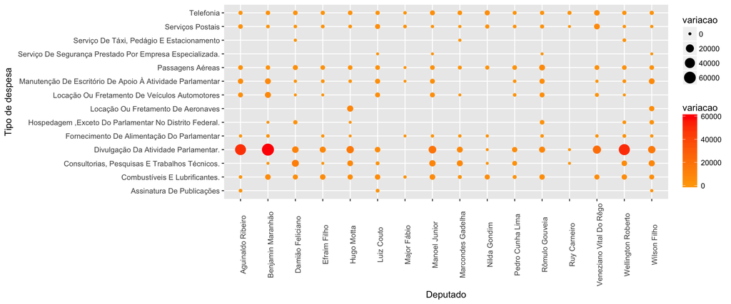

```r
# dados_sum <- dados_pb %>%
#   group_by(nome, descricao) %>%
#   summarise(max = max(valor_liq), min = min(valor_liq)) %>%
#   arrange(max-min)
#
# dados_sum %>%
#   ggplot(aes(x = reorder(descricao, max-min))) +
#   geom_errorbar(aes(ymax = max, ymin = min)) +
#   theme(axis.text.x = element_text(angle = 90))+
#   facet_grid(nome ~ .)
#ggsave(file="grafico.png", limitsize = FALSE)

dados_sum <- dados_pb %>%
  group_by(nome, descricao) %>%
  summarise(variacao = (max(valor_liq) - min(valor_liq)))

dados_sum %>%
  ggplot(aes(x = nome, y = descricao)) +
  geom_point(aes(size = variacao, colour = variacao)) +
  scale_colour_gradient(low = "orange", high = "red") +
  theme(axis.text.x = element_text(angle = 90)) +
  xlab("Deputado") +
  ylab("Tipo de despesa")
```

O gráfico acima mostra que **houve principalmente uma variação muito grande nas despesas de *Divulgação da Atividade Parlamentar* para 3 deputados em especial: Aguinaldo Ribeiro, Benjamin Maranhão e Wellington Roberto**. Vamos analisar então os valores mínimo e máximo desse tipo de despesa para cada um desses deputados:

```r
kable(dados_pb %>%
  filter(nome == "Aguinaldo Ribeiro" & descricao == "Divulgação Da Atividade Parlamentar.") %>%
  filter(valor_liq == min(valor_liq)))
```

| partido | nome | uf | descricao | valor_liq | id_deputado |
| --- | --- | --- | --- | --- | --- |
| PP | Aguinaldo Ribeiro | PB | Divulgação Da Atividade Parlamentar. | 5200 | 160527 |

```r
kable(dados_pb %>%
  group_by(nome, descricao) %>%
  filter(nome == "Aguinaldo Ribeiro" & descricao == "Divulgação Da Atividade Parlamentar.") %>%
  summarise(min = min(valor_liq), max = max(valor_liq)))
```

| nome | descricao | min | max |
| --- | --- | --- | --- |
| Aguinaldo Ribeiro | Divulgação Da Atividade Parlamentar. | 5200 | 54000 |

```r
kable(dados_pb %>%
  group_by(nome, descricao) %>%
  filter(nome == "Benjamin Maranhão" & descricao == "Divulgação Da Atividade Parlamentar.") %>%
  summarise(min = min(valor_liq), max = max(valor_liq)))
```

| nome | descricao | min | max |
| --- | --- | --- | --- |
| Benjamin Maranhão | Divulgação Da Atividade Parlamentar. | 238.33 | 64000 |

```r
kable(dados_pb %>%
  group_by(nome, descricao) %>%
  filter(nome == "Wellington Roberto" & descricao == "Divulgação Da Atividade Parlamentar.") %>%
  summarise(min = min(valor_liq), max = max(valor_liq)))
```

| nome | descricao | min | max |
| --- | --- | --- | --- |
| Wellington Roberto | Divulgação Da Atividade Parlamentar. | 500 | 51000 |

Como esperado, esses deputados apresentaram uma variação muito grande para uma mesma despesa, principalmente Benjamim Maranhão.

## 4. Conclusões

Este trabalho analisou os dados dos deputados paraibanos durante o período de Janeiro de 2015 à Julho de 2016. De acordo com as analises, pode-se concluir:

- Somente o PMDB e o PSDB tiveram mais de um representante na câmara;
- A média dos valores líquidos registrados é de R$891,77. A mediana é R$230,02;
- Entretanto, cada deputado gastou, em média, R$472.415,20;
- Os gastos mais comuns são relacionados a transporte dos deputados: *Passagens aéreas* e *Combustíveis e Lubrificantes*;
- No entanto, os deputados paraibanos gastam mais dinheiro com *Divulgação da Atividade Parlamentar*, seguido de *Passagens Aéreas*;
- Os tipos de despesas menos utilizados pelos deputados são: *Assinatura de Publicações* e *Serviço de Segurança Prestado por Empresas Especializadas*;
- A *Divulgação da Atividade Parlamentar* é a despesas que mais apresenta variação de valores;